# Untitled20 (1)

```python
!pip install pdfminer3
!pip install pyLDAvis
```

### Reading multiple pdf file(PM Speeches) at once and saving it into text file.

```python
from pdfminer3.layout import LAParams, LTTextBox
from pdfminer3.pdfpage import PDFPage
from pdfminer3.pdfinterp import PDFResourceManager
from pdfminer3.pdfinterp import PDFPageInterpreter
from pdfminer3.converter import PDFPageAggregator
from pdfminer3.converter import TextConverter
import io
import os

files = []
for file in os.listdir("./"):
    if file.endswith(".pdf"):
        files.append(file)

resource_manager = PDFResourceManager()
fake_file_handle = io.StringIO()
converter = TextConverter(resource_manager, fake_file_handle, laparams=LAParams())
page_interpreter = PDFPageInterpreter(resource_manager, converter)

for file in files:
  print("{0} rendering in progress". format(file))
  with open(file, 'rb') as fh:
    for page in PDFPage.get_pages(fh,
                                  caching=True,
                                  check_extractable=True):
      page_interpreter.process_page(page)

      text = fake_file_handle.getvalue()

    # print(text)

    with open("sample.txt",'a',encoding = 'utf-8') as f:
        f.write(text)

# close open handles
converter.close()
fake_file_handle.close()
```

### Creating wordclound without pre processing

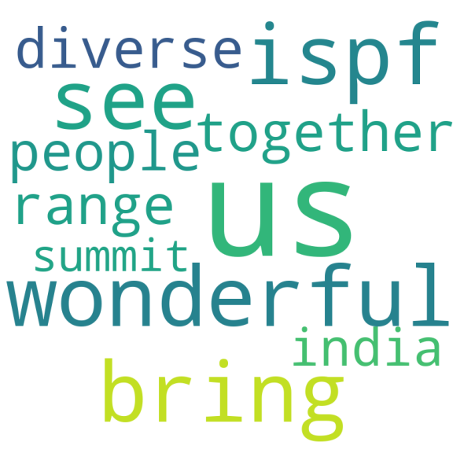

```python
# Python program to generate WordCloud

# importing all necessery modules
from wordcloud import WordCloud, STOPWORDS
import matplotlib.pyplot as plt
import pandas as pd

# Reads the created text file
df = pd.read_fwf("/content/sample.txt")

comment_words = ''
stopwords = set(STOPWORDS)

# iterate through the csv file
for val in df:

	# typecaste each val to string
	val = str(val)

	# split the value
	tokens = val.split()

	# Converts each token into lowercase
	for i in range(len(tokens)):
		tokens[i] = tokens[i].lower()

	comment_words += " ".join(tokens)+" "

wordcloud = WordCloud(width = 800, height = 800,
				background_color ='white',
				stopwords = stopwords,
				min_font_size = 10).generate(comment_words)

# plot the WordCloud image
plt.figure(figsize = (8, 8), facecolor = None)
plt.imshow(wordcloud)
plt.axis("off")
plt.tight_layout(pad = 0)

plt.show()
```

```python
import nltk
from nltk import FreqDist
nltk.download('stopwords') # run this one time
```

```
True
```

```python
import pandas as pd
pd.set_option("display.max_colwidth", 200)
import numpy as np
import re
import spacy

import gensim
from gensim import corpora

# libraries for visualization
import pyLDAvis
import pyLDAvis.gensim
import matplotlib.pyplot as plt
import seaborn as sns
%matplotlib inline
```

```python
df = pd.read_fwf('/content/sample.txt', header=None)
df.head()
```

|  | 0 |
| --- | --- |
| 0 | It is wonderful to see US-ISPF bring together a diverse range of people for the US India Summit 2020. The |
| 1 | work ofthe US-ISPF in bringing India and USA closer is commendable. |
| 2 | I have known John Chambers for many years now. His affection towards India is very strong. A few years |
| 3 | ago he was awarded the ‘Padma Shri’. |
| 4 | Friends, |

### Data Preprocessing

```python
# function to plot most frequent terms
def freq_words(x, terms = 30):
  all_words = ' '.join([text for text in x])
  all_words = all_words.split()

  fdist = FreqDist(all_words)
  words_df = pd.DataFrame({'word':list(fdist.keys()), 'count':list(fdist.values())})

  # selecting top 20 most frequent words
  d = words_df.nlargest(columns="count", n = terms)
  plt.figure(figsize=(20,5))
  ax = sns.barplot(data=d, x= "word", y = "count")
  ax.set(ylabel = 'Count')
  plt.show()
```

```python
df.columns
```

```
Int64Index([0], dtype='int64')
```

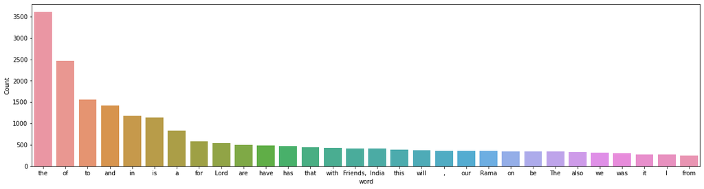

```python
freq_words(df[0])
```

Most common words are ‘the’, ‘and’, ‘to’, so on and so forth. These words are not so important for our task and they do not tell any story. We’ have to get rid of these kinds of words. Before that let’s remove the punctuations and numbers from our text data.

```python
# remove unwanted characters, numbers and symbols
df['Comment'] = df[0].str.replace("[^a-zA-Z#]", " ")
```

```python
from nltk.corpus import stopwords
stop_words = stopwords.words('english')
```

```python
# function to remove stopwords
def remove_stopwords(rev):
    rev_new = " ".join([i for i in rev if i not in stop_words])
    return rev_new

# remove short words (length < 3)
df['Comment'] = df['Comment'].apply(lambda x: ' '.join([w for w in x.split() if len(w)>3]))

# remove stopwords from the text
reviews = [remove_stopwords(r.split()) for r in df['Comment']]

# make entire text lowercase
reviews = [r.lower() for r in reviews]
```

Let’s again plot the most frequent words and see if the more significant words have come out.

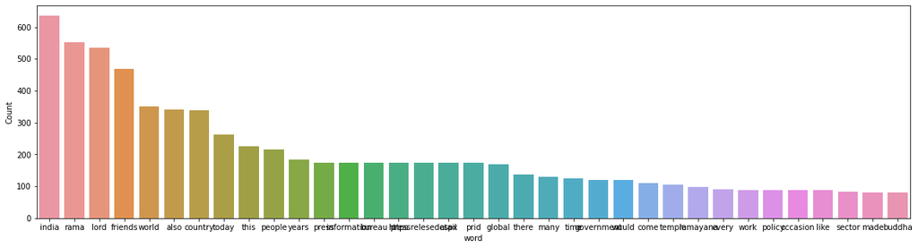

```python
freq_words(reviews, 35)
```

To further remove noise from the text we can use lemmatization from the spaCy library. It reduces any given word to its base form thereby reducing multiple forms of a word to a single word.

```python
!python -m spacy download en # one time run
```

```
✔ Download and installation successful
You can now load the model via spacy.load('en_core_web_sm')
✔ Linking successful
/usr/local/lib/python3.6/dist-packages/en_core_web_sm -->
/usr/local/lib/python3.6/dist-packages/spacy/data/en
You can now load the model via spacy.load('en')
```

```python
nlp = spacy.load('en', disable=['parser', 'ner'])

def lemmatization(texts, tags=['NOUN', 'ADJ']): # filter noun and adjective
       output = []
       for sent in texts:
             doc = nlp(" ".join(sent))
             output.append([token.lemma_ for token in doc if token.pos_ in tags])
       return output
```

Let’s tokenize the comments and then lemmatize the tokenized comments.

```python
tokenized_reviews = pd.Series(reviews).apply(lambda x: x.split())
print(tokenized_reviews[1])
```

```
['work', 'ofthe', 'ispf', 'bringing', 'india', 'closer', 'commendable']
```

```python
reviews_2 = lemmatization(tokenized_reviews)
print(reviews_2[1]) # print lemmatized review
```

```
['commendable']
```

As you can see, we have not just lemmatized the words but also filtered only nouns and adjectives. Let’s de-tokenize the lemmatized reviews and plot the most common words.

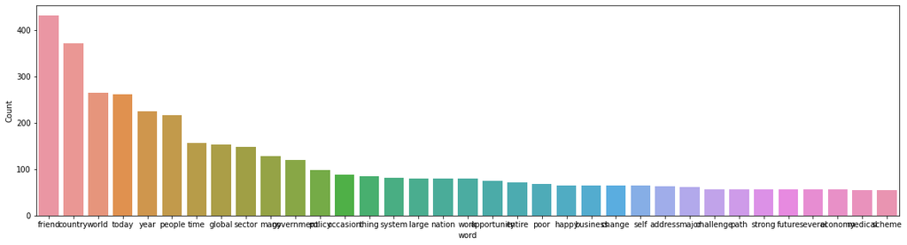

```python
reviews_3 = []
for i in range(len(reviews_2)):
    reviews_3.append(' '.join(reviews_2[i]))

df['reviews'] = reviews_3

freq_words(df['reviews'], 35)
```

It seems that now most frequent terms in our data are relevant. We can now go ahead and start building our topic model.

### Building LDA model

We will start by creating the term dictionary of our corpus, where every unique term is assigned an index

```python
dictionary = corpora.Dictionary(reviews_2)
```

Then we will convert the list of reviews (reviews_2) into a Document Term Matrix using the dictionary prepared above.

```python
doc_term_matrix = [dictionary.doc2bow(rev) for rev in reviews_2]
```

```python
# Creating the object for LDA model using gensim library
LDA = gensim.models.ldamodel.LdaModel

# Build LDA model
lda_model = LDA(corpus=doc_term_matrix, id2word=dictionary, num_topics=7, random_state=100,
                chunksize=1000, passes=50)
```

[output not shown]

```python
lda_model.print_topics()
```

```
[(0,
  '0.036*"year" + 0.028*"world" + 0.023*"youth" + 0.021*"large" + 0.020*"business" + 0.019*"poor" + 0.018*"last" + 0.015*"global" + 0.014*"challenge" + 0.013*"medical"'),
 (1,
  '0.040*"government" + 0.028*"country" + 0.026*"work" + 0.024*"important" + 0.018*"class" + 0.018*"policy" + 0.015*"level" + 0.015*"happy" + 0.014*"line" + 0.014*"blessing"'),
 (2,
  '0.034*"sector" + 0.025*"economy" + 0.024*"year" + 0.019*"step" + 0.018*"world" + 0.015*"infrastructure" + 0.014*"different" + 0.011*"strong" + 0.010*"entire" + 0.010*"thousand"'),
 (3,
  '0.052*"time" + 0.026*"major" + 0.023*"nation" + 0.021*"decision" + 0.019*"several" + 0.019*"reform" + 0.018*"sector" + 0.016*"investment" + 0.015*"system" + 0.015*"today"'),
 (4,
  '0.083*"country" + 0.045*"today" + 0.026*"policy" + 0.022*"address" + 0.020*"many" + 0.017*"world" + 0.015*"farmer" + 0.013*"mind" + 0.013*"much" + 0.012*"solution"'),
 (5,
  '0.056*"people" + 0.044*"country" + 0.029*"self" + 0.025*"reliant" + 0.024*"today" + 0.022*"world" + 0.018*"effort" + 0.015*"education" + 0.014*"time" + 0.013*"whole"'),
 (6,
  '0.178*"friend" + 0.025*"change" + 0.024*"thing" + 0.021*"path" + 0.020*"global" + 0.019*"private" + 0.018*"opportunity" + 0.013*"government" + 0.012*"occasion" + 0.012*"strength"')]
```

```python
t = str(lda_model.print_topics())
```

**Let's focus on the dominant topic and its percentage contribution in each document**

```python
def format_topics_sentences(ldamodel, corpus, texts):
    # Init output
    sent_topics_df = pd.DataFrame()

    # Get main topic in each document
    for i, row_list in enumerate(ldamodel[corpus]):
        row = row_list[0] if ldamodel.per_word_topics else row_list
        # print(row)
        row = sorted(row, key=lambda x: (x[1]), reverse=True)
        # Get the Dominant topic, Perc Contribution and Keywords for each document
        for j, (topic_num, prop_topic) in enumerate(row):
            if j == 0:  # => dominant topic
                wp = ldamodel.show_topic(topic_num)
                topic_keywords = ", ".join([word for word, prop in wp])
                sent_topics_df = sent_topics_df.append(pd.Series([int(topic_num), round(prop_topic,4), topic_keywords]), ignore_index=True)
            else:
                break
    sent_topics_df.columns = ['Dominant_Topic', 'Perc_Contribution', 'Topic_Keywords']

    # Add original text to the end of the output
    contents = pd.Series(texts)
    sent_topics_df = pd.concat([sent_topics_df, contents], axis=1)
    return(sent_topics_df)
```

```python
df_topic_sents_keywords = format_topics_sentences(ldamodel=lda_model, corpus=doc_term_matrix, texts=reviews_3)

# Format
df_dominant_topic = df_topic_sents_keywords.reset_index()
df_dominant_topic.columns = ['Document_No', 'Dominant_Topic', 'Topic_Perc_Contrib', 'Keywords', 'Text']
df_dominant_topic.head(10)
```

|  | Document_No | Dominant_Topic | Topic_Perc_Contrib | Keywords | Text |
| --- | --- | --- | --- | --- | --- |
| 0 | 0 | 4.0 | 0.8774 | country, today, policy, address, many, world, farmer, mind, much, solution | wonderful ispf diverse range people summit |
| 1 | 1 | 4.0 | 0.5714 | country, today, policy, address, many, world, farmer, mind, much, solution | commendable |
| 2 | 2 | 2.0 | 0.8568 | sector, economy, year, step, world, infrastructure, different, strong, entire, thousand | many year affection strong year |
| 3 | 3 | 0.0 | 0.1429 | year, world, youth, large, business, poor, last, global, challenge, medical |  |
| 4 | 4 | 6.0 | 0.5714 | friend, change, thing, path, global, private, opportunity, government, occasion, strength | friend |
| 5 | 5 | 0.0 | 0.8284 | year, world, youth, large, business, poor, last, global, challenge, medical | theme relevant challenge year |
| 6 | 6 | 6.0 | 0.7856 | friend, change, thing, path, global, private, opportunity, government, occasion, strength | global pandemic testing |
| 7 | 7 | 3.0 | 0.8570 | time, major, nation, decision, several, reform, sector, investment, system, today | public health system economic system |
| 8 | 8 | 4.0 | 0.8928 | country, today, policy, address, many, world, farmer, mind, much, solution | current situation fresh mind mind approach development |
| 9 | 9 | 3.0 | 0.5714 | time, major, nation, decision, several, reform, sector, investment, system, today | cooperationbetween |

**Most representative sentence of each topic**

```python
# Display setting to show more characters in column
pd.options.display.max_colwidth = 100

sent_topics_sorteddf_mallet = pd.DataFrame()
sent_topics_outdf_grpd = df_topic_sents_keywords.groupby('Dominant_Topic')

for i, grp in sent_topics_outdf_grpd:
    sent_topics_sorteddf_mallet = pd.concat([sent_topics_sorteddf_mallet,
                                             grp.sort_values(['Perc_Contribution'], ascending=False).head(1)],
                                            axis=0)

# Reset Index
sent_topics_sorteddf_mallet.reset_index(drop=True, inplace=True)

# Format
sent_topics_sorteddf_mallet.columns = ['Topic_Num', "Topic_Perc_Contrib", "Keywords", "Representative Text"]

# Show
sent_topics_sorteddf_mallet.head(10)
```

|  | Topic_Num | Topic_Perc_Contrib | Keywords | Representative Text |
| --- | --- | --- | --- | --- |
| 0 | 0.0 | 0.9142 | year, world, youth, large, business, poor, last, global, challenge, medical | less work underway world large housing program renewable energy |
| 1 | 1.0 | 0.9046 | government, country, work, important, class, policy, level, happy, line, blessing | banking credit digital payment insurance million initiative world |
| 2 | 2.0 | 0.9141 | sector, economy, year, step, world, infrastructure, different, strong, entire, thousand | step possible minimal impact indian economy economy policy clear |
| 3 | 3.0 | 0.9340 | time, major, nation, decision, several, reform, sector, investment, system, today | sacred soil water major religious site sacred river nation culture spirit place |
| 4 | 4.0 | 0.9047 | country, today, policy, address, many, world, farmer, mind, much, solution | personnel excellent uality caliber state country proud much |
| 5 | 5.0 | 0.9220 | people, country, self, reliant, today, world, effort, education, time, whole | learned saint guru epitome austerity today corner country dear fellow |
| 6 | 6.0 | 0.9141 | friend, change, thing, path, global, private, opportunity, government, occasion, strength | people section society matter today general public registering opinion |

**Frequency distribution of word count in Documents**

[figure not shown]

```python
doc_lens = [len(d) for d in df_dominant_topic.Text]

# Plot
plt.figure(figsize=(16,7), dpi=160)
plt.hist(doc_lens, bins = 1000, color='navy')
plt.text(750, 100, "Mean   : " + str(round(np.mean(doc_lens))))
plt.text(750,  90, "Median : " + str(round(np.median(doc_lens))))
plt.text(750,  80, "Stdev   : " + str(round(np.std(doc_lens))))
plt.text(750,  70, "1%ile    : " + str(round(np.quantile(doc_lens, q=0.01))))
plt.text(750,  60, "99%ile  : " + str(round(np.quantile(doc_lens, q=0.99))))

plt.gca().set(xlim=(0, 1000), ylabel='Number of Documents', xlabel='Document Word Count')
plt.tick_params(size=16)
plt.xticks(np.linspace(0,1000,9))
plt.title('Distribution of Document Word Counts', fontdict=dict(size=22))
plt.show()
```

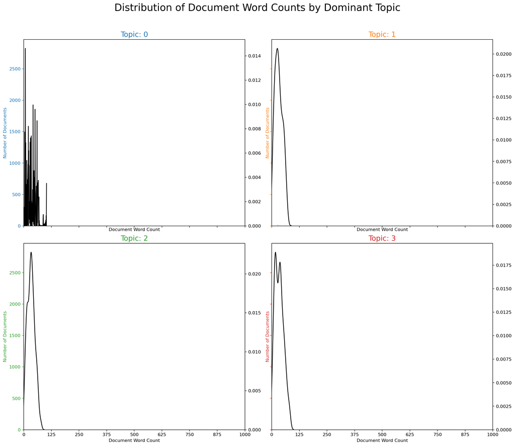

```python
import seaborn as sns
import matplotlib.colors as mcolors
cols = [color for name, color in mcolors.TABLEAU_COLORS.items()]  # more colors: 'mcolors.XKCD_COLORS'

fig, axes = plt.subplots(2,2,figsize=(16,14), dpi=160, sharex=True, sharey=True)

for i, ax in enumerate(axes.flatten()):
    df_dominant_topic_sub = df_dominant_topic.loc[df_dominant_topic.Dominant_Topic == i, :]
    doc_lens = [len(d) for d in df_dominant_topic_sub.Text]
    ax.hist(doc_lens, bins = 1000, color=cols[i])
    ax.tick_params(axis='y', labelcolor=cols[i], color=cols[i])
    sns.kdeplot(doc_lens, color="black", shade=False, ax=ax.twinx())
    ax.set(xlim=(0, 1000), xlabel='Document Word Count')
    ax.set_ylabel('Number of Documents', color=cols[i])
    ax.set_title('Topic: '+str(i), fontdict=dict(size=16, color=cols[i]))

fig.tight_layout()
fig.subplots_adjust(top=0.90)
plt.xticks(np.linspace(0,1000,9))
fig.suptitle('Distribution of Document Word Counts by Dominant Topic', fontsize=22)
plt.show()
```

**Word cloud of top N keyword in each topic**

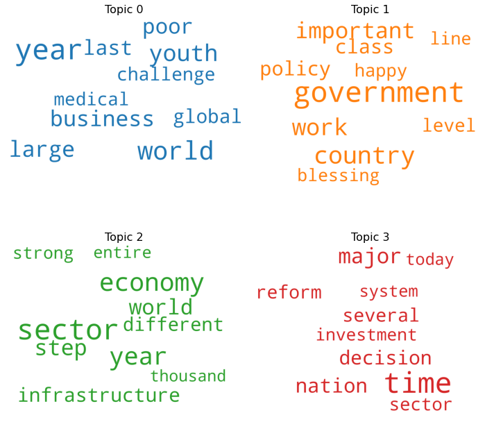

```python
# 1. Wordcloud of Top N words in each topic
from matplotlib import pyplot as plt
from wordcloud import WordCloud, STOPWORDS
import matplotlib.colors as mcolors

cols = [color for name, color in mcolors.TABLEAU_COLORS.items()]  # more colors: 'mcolors.XKCD_COLORS'

cloud = WordCloud(stopwords=stop_words,
                  background_color='white',
                  width=2500,
                  height=1800,
                  max_words=10,
                  colormap='tab10',
                  color_func=lambda *args, **kwargs: cols[i],
                  prefer_horizontal=1.0)

topics = lda_model.show_topics(formatted=False)

fig, axes = plt.subplots(2, 2, figsize=(10,10), sharex=True, sharey=True)

for i, ax in enumerate(axes.flatten()):
    fig.add_subplot(ax)
    topic_words = dict(topics[i][1])
    cloud.generate_from_frequencies(topic_words, max_font_size=300)
    plt.gca().imshow(cloud)
    plt.gca().set_title('Topic ' + str(i), fontdict=dict(size=16))
    plt.gca().axis('off')


plt.subplots_adjust(wspace=0, hspace=0)
plt.axis('off')
plt.margins(x=0, y=0)
plt.tight_layout()
plt.show()
```

**Word count of Topic Keywords**

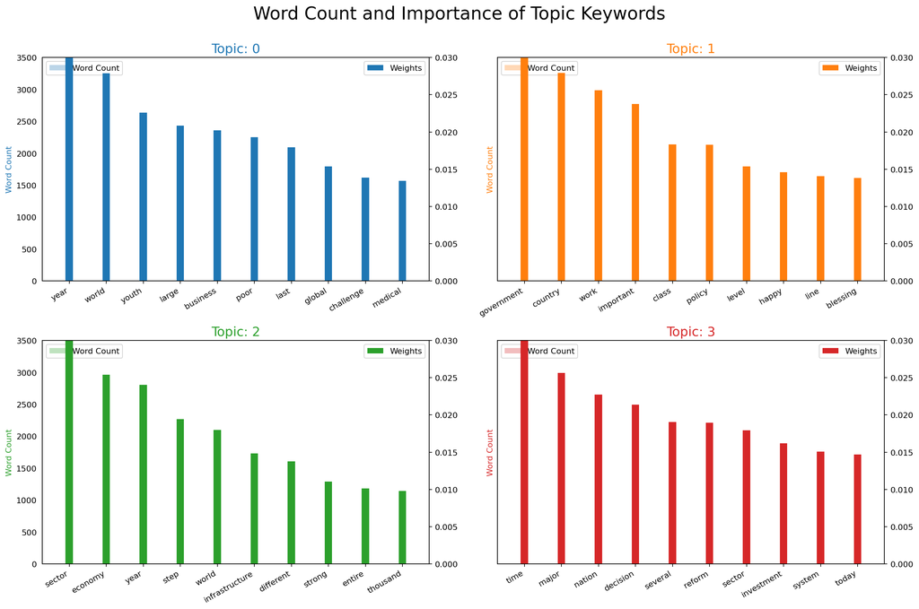

```python
from collections import Counter
topics = lda_model.show_topics(formatted=False)
data_flat = [w for w_list in reviews_3 for w in w_list]
counter = Counter(data_flat)

out = []
for i, topic in topics:
    for word, weight in topic:
        out.append([word, i , weight, counter[word]])

df = pd.DataFrame(out, columns=['word', 'topic_id', 'importance', 'word_count'])

# Plot Word Count and Weights of Topic Keywords
fig, axes = plt.subplots(2, 2, figsize=(16,10), sharey=True, dpi=160)
cols = [color for name, color in mcolors.TABLEAU_COLORS.items()]
for i, ax in enumerate(axes.flatten()):
    ax.bar(x='word', height="word_count", data=df.loc[df.topic_id==i, :], color=cols[i], width=0.5, alpha=0.3, label='Word Count')
    ax_twin = ax.twinx()
    ax_twin.bar(x='word', height="importance", data=df.loc[df.topic_id==i, :], color=cols[i], width=0.2, label='Weights')
    ax.set_ylabel('Word Count', color=cols[i])
    ax_twin.set_ylim(0, 0.030); ax.set_ylim(0, 3500)
    ax.set_title('Topic: ' + str(i), color=cols[i], fontsize=16)
    ax.tick_params(axis='y', left=False)
    ax.set_xticklabels(df.loc[df.topic_id==i, 'word'], rotation=30, horizontalalignment= 'right')
    ax.legend(loc='upper left'); ax_twin.legend(loc='upper right')

fig.tight_layout(w_pad=2)
fig.suptitle('Word Count and Importance of Topic Keywords', fontsize=22, y=1.05)
plt.show()
```

### Topic Viusalization

To visualize our topics in a 2-dimensional space we will use the pyLDAvis library. This visualization is interactive in nature and displays topics along with the most relevant words.

```python
# Visualize the topics
pyLDAvis.enable_notebook()
vis = pyLDAvis.gensim.prepare(lda_model, doc_term_matrix, dictionary)
vis
```

[interactive chart not shown]

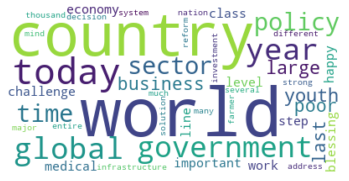

```python
from wordcloud import WordCloud, STOPWORDS, ImageColorGenerator
wordcloud = WordCloud(min_font_size=10, max_words=5000, background_color="white").generate(t)
plt.figure()
plt.imshow(wordcloud, interpolation="bilinear")
plt.axis("off")
plt.show()
```